# Replication of Bird, Karolyi, and Ruchti (2019, JAE)

Shunsuke Matsuno

2020/6/1

# Required libraries

```r
easypackages::libraries('tidyverse', 'ggplot2', 'NumbersGame')
```

# Introduction

- This note replicates Bird, Karolyi, and Ruchti ‘Understanding the “numbers game”’ (BKR; 2019, JAE).

# Simulating the data

- Since I don’t have access to the original data, I simulate the “observed” data using the estimated parameters in BKR.

## Parameters

- $\theta = (\eta, \gamma, \psi^2, \zeta)$.

```r
set.seed(2020)

# The estimated values that apperar in Table 4
eta <- 0.5  # marginal cost
gamma <- 2.0817    # curvature
psi2 <- 0.8201   # variance
zeta <- 3.7105    # variance multiplier
theta <- c(eta, gamma, psi2, zeta)
```

## Benefit function

- Since the estimates of full model (coefficients on polynomials) are not reported, I approximate the capital market benefit function by `compute_benefit.R`.

```r
compute_benefit
```

```
function(R){
  # This function computes the capital market benefit of earnings surprise.
  # Since the estimates of coefficients on polynomial terms are not reported in the origina paper,
  #  I roughly approximate the functional form of Fig. 1.
  # You may want to change the functional form of this function.

  # # return is in terms of real number (not percent)
  # benefit <- (R < 0) * (0.01 * R - 1/100) + (R >= 0 ) * (0.01 * R + 0.5/100)

  # return is in terms of percent
  benefit <- (R < 0) * (0.01 * R - 1) + (R >= 0 ) * (0.01 * R + 0.5)

  return(benefit)

}
<bytecode: 0x00000000292a1a30>
<environment: namespace:NumbersGame>
```

## Latent earnings distribution

- I assume that latent earnings distribution is generated by normal distribution.
- I set the number of firms (observations) to $100,000$.
  - In BKR, the number of observations is $49,604$.
- I use the following multinomial distribution as a discretized normal:

$$e \sim \textit{Multi}(N, P)\\
\mathcal{X} = \{ -20,-19,\dots,0,\dots,19,20 \} \\
P = (\phi(-20),\dots,\phi(20)))$$

```r
simulate_firm
```

```
function(sigma, S){
  # This function simulates firms latent earning surprise distribution
  # The distirubiton is assumed to be multinomial distribution with normal density probablitities.
  # sigma: the sd of normal dist

  df_firm <- tibble(
    firm = 1:S,
    e = sample(x = -20:20,
               size = S,
               replace = TRUE,
               prob = dnorm(-20:20, 0, sigma)))

  return(df_firm)

}
<bytecode: 0x0000000029480730>
<environment: namespace:NumbersGame>
```

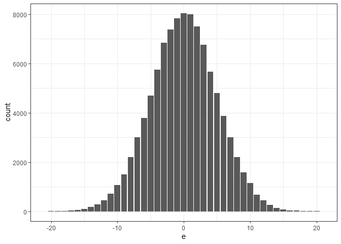

```r
# number of firms
N <- 100000
sigma <- 5

df_firm <- simulate_firm(S = N, sigma)

ggplot(df_firm, aes(x = e)) +
  geom_bar() +
  xlim(-21, 21) +
  theme_bw()
```

## Manipulation

- Each firm decides the amount of manipulation, $m$, according to the maximization problem.
- `compute_utility` computes the following utility:
  $$u_{\text {Discrete}}(b, m, \theta)=\sum_{-20}^{20} \phi_{m, \theta}(\varepsilon) \mathcal{B}(b+m+\varepsilon) d \varepsilon-\beta_{b} m^{\gamma}$$

```r
compute_utility
```

```
function(e, m, beta, theta){
  # This function computes the utility of manipulation for each state (e).
  if(m == 0){
    # If the firm decides not to engage in the manipulation, then the reported surprise is e.
    utility <- compute_benefit(e)
  }else{
    if(theta[3] == 0){
      # no uncertanty
      E_benefit <- compute_benefit(e + m)

    }else{
      # uncertanty of manipulation
      eps <- -20:20
      prob_eps <- extraDistr::ddnorm(eps, mean = 0, sd = sqrt( (1 + theta[4]*(m - 1)) * theta[3] ))
      report <- e + m + eps
      E_benefit <- sum(prob_eps * compute_benefit(report))
    }
    cost <- beta * (m^theta[2])
    utility <- E_benefit - cost
  }
  return(utility)
}
<bytecode: 0x000000002970b528>
<environment: namespace:NumbersGame>
```

- Since I don’t have the original data, I am assuming the following benefit function.
  - There is a jump by $1.5$ at $R=0$.

```r
compute_optimal_manipulation_simulated
```

```
function(df_firm, theta, S){
  # This function is used to compute the optimal behavior with the simulated data.
  # Since the input is simulated data, we know the latent earnings, e.

  # draw of beta
  df_firm <- df_firm %>%
    mutate(beta = runif(S, 0, 2 * theta[1]))


  # the amount of manipulation ranging from 0 to 40 - e for each firm
  df_manipulation <- tibble(
    e = rep(-20:20, each = 41),
    m = rep(0:40, times = 41)
  ) %>%
    filter(m + e <= 20) %>%      # the maximum amount of manipulation is 20 - b.
    select(e, m)

  # join firm-level data and manipulation data
  df_firm_utility <- left_join(df_firm, df_manipulation, by = 'e')

  # compute utility
  utility <- df_firm_utility %>%
    select(e, m, beta) %>%
    mutate(utility = pmap_dbl(.l = ., .f = compute_utility, theta = theta)) %>%
    pull(utility)

  # compute optimal behavior for negative firms
  df_firm_utility <- df_firm_utility %>%
    mutate(utility = utility) %>%     # computed utility
    group_by(firm) %>%
    mutate(max_utility = if_else(utility == max(utility), 1, 0)) %>%     # indicating max utility
    ungroup() %>%
    mutate(m_opt = m * max_utility) %>%     # optimal amount of manipulation
    filter(max_utility == 1) %>%
    mutate(eps_after = map2_dbl(m_opt, e, generate_shock, theta = theta)) %>%    # uncertainty of manipulation is drawn according to the amount of manipulation
    mutate(R = e + m_opt + eps_after) %>%     # report surprise
    select(firm, e, beta, m_opt, eps_after, R)

  return(df_firm_utility)
}
<bytecode: 0x00000000298aebd0>
<environment: namespace:NumbersGame>
```

```r
df_firm_utility <- compute_optimal_manipulation_simulated(df_firm, theta, S = N)
df_firm_utility
```

```
# A tibble: 100,000 x 6
    firm     e    beta m_opt eps_after     R
   <int> <int>   <dbl> <dbl>     <dbl> <dbl>
 1     1    -5 0.00104    13         2    10
 2     2     3 0.0478      0         0     3
 3     3     4 0.402       0         0     4
 4     4    -3 0.241       0         0    -3
 5     5    -1 0.104       1         0     0
 6     6     0 0.129       0         0     0
 7     7    -1 0.748       1         1     1
 8     8     3 0.575       0         0     3
 9     9     0 0.174       0         0     0
10    10     4 0.988       0         0     4
# ... with 99,990 more rows
```

- `plot_latent_reported.R` plots the latent distribution and the reported distribution.

```r
plot_latent_reported
```

```
function(df_firm_utility){
  df_summarised_R <- df_firm_utility %>%
    group_by(R) %>%
    summarise(freq_R = n(),
              .groups = "drop") %>%
    rename(bin = R)
  df_summarised_e <- df_firm_utility %>%
    group_by(e) %>%
    summarise(freq_e = n(),
              .groups = "drop") %>%
    rename(bin = e)

  df_summarised <- full_join(df_summarised_R, df_summarised_e, by = 'bin') %>%
    pivot_longer(-bin, names_to = 'type', values_to = 'freq')

  g <- ggplot(df_summarised, aes(x = bin, y = freq, fill = type)) +
    geom_bar(aes(fill = type), stat = 'identity', position = 'dodge', alpha = .8)+
    xlim(-21,21) +
    scale_fill_hue(name = "type", labels = c(freq_e = "latent", freq_R ='reported')) +
    theme_bw()

  plot(g)
}
<bytecode: 0x0000000029b06770>
<environment: namespace:NumbersGame>
```

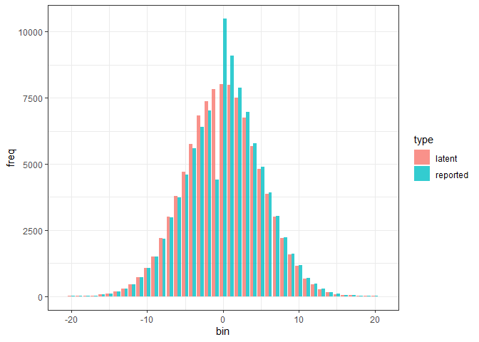

```r
# plot
plot_latent_reported(df_firm_utility)
```

- The ‘empirical’ distribution of earnings surprises above is a bit drastic than BKR’s empirical distribution.
  - Compare the following graph with Fig.2.
  - This is because my simulation assumes that the empirical distribution is solely determined by the optimization behavior of BKR’s model, while in reality variety of other factors come into play.

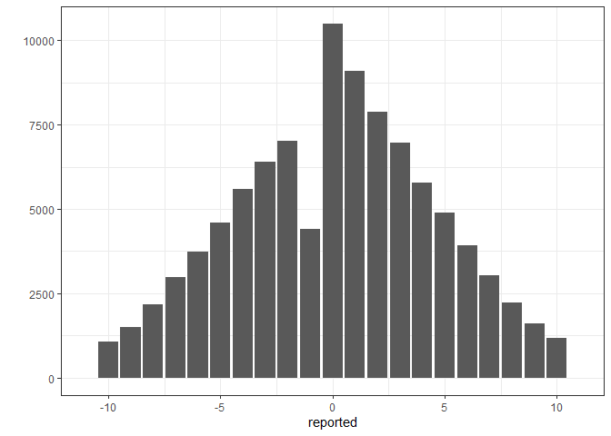

```r
qplot(df_firm_utility$R, geom = 'bar', xlim = c(-11,11), xlab = 'reported') +
  theme_bw()
```

# Estimation

- Regarding the simulated data as ‘observed’ data, I recover the parameter $\theta$ by BKR method.
- See `SummaryBKR.pdf` for the step-by-step estimation procedure.

```r
df_observed <- df_firm_utility %>%      # df_firm_utility is the 'true' data
  select(firm, R)                       # Discard the information that cannot be observed (by researcher)
df_observed
```

```
# A tibble: 100,000 x 2
    firm     R
   <int> <dbl>
 1     1    10
 2     2     3
 3     3     4
 4     4    -3
 5     5     0
 6     6     0
 7     7     1
 8     8     3
 9     9     0
10    10     4
# ... with 99,990 more rows
```

```r
# save data
save(df_observed, file = '../output/data/df_observed.RData')

# load data
load(file = '../output/data/df_observed.RData')
```

## Step 1. Candidate $\theta$

- I set the initial $\theta$ to be the true $\theta$.

```r
theta_init <- theta
```

## Step 2. Simulate optimal firm behavior

- I compute the transition matrix, $P$.
- Considering the computational cost, I set the number of simulations $S$ to be $1,000$.
  - The original paper uses $S=10,000$.
- `compute_P.R` computes the matrix $P(\theta)$ that maps latent earnings to reported earnings.
  - `compute_P.R` internally calls `compute_optimal_manipulation_for_e.R`, which computes the empirical probability of manipulation for each bin.
  - `compute_P()` uses parallel computation by default. If you prefer an usual sequential computation, set `parallel = FALSE`.

```r
compute_P
```

```
function(theta, S = 1000, parallel = TRUE){
  e_vec <- -20:20    # each state (bin)
  result <- array(dim = c(S, length(e_vec)))   # S x 41  array

  # compute m_opt for each e (b)
  if(parallel == TRUE){
    # parallel computation

    ## register
    library(doParallel)
    cl <- parallel::makePSOCKcluster(parallel::detectCores(logical = FALSE))
    doParallel::registerDoParallel(cl)

    result <- foreach (i = seq_along(e_vec),
                    .packages = c('dplyr', 'purrr', 'NumbersGame','tidyr'),
                    .combine = 'cbind') %dopar% {
                      compute_optimal_manipulation_for_e(e_vec[i], theta, S)$R
                    }

    ## kill finished tasks
    parallel::stopCluster(cl)
  }else{
    # sequential computation
    for(i in seq_along(e_vec)){
      result_temp <- compute_optimal_manipulation_for_e(e_vec[i], theta, S)
      result[,i] <- result_temp$R
    }
  }

  # compute P
  P <- array(dim = c(41, 41))


  for(b in 1:NROW(P)){
    for(j in 1:NCOL(P)){
      P[j, b] <- sum(result[,b] == j - 21) / S
    }
  }


  return(P)

}
<bytecode: 0x0000000025870ec8>
<environment: namespace:NumbersGame>
```

```r
compute_optimal_manipulation_for_e
```

```
function(e, theta, S = 1000){
  # This function is used to simulate the optimal behavior for each bin over [-20, 20]
  # This function computes optimal behavior for given e.
  # Output: optimal amount of manipulation and epsilon. [m_{b,s=1:S}, eps_{b,s=1:S}]

  # draw of beta
  df_firm <- tibble(
    firm = 1:S,
    e = e,
    beta = runif(S, 0, 2 * theta[1])
  )

  # the amount of manipulation ranging from 0 to 20 - e for each firm
  df_manipulation <- tibble(
    e = rep(-20:20, each = 41),
    m = rep(0:40, times = 41)
  ) %>%
    filter(m + e <= 20) %>%      # the maximum amount of manipulation is 20 - b.
    select(e, m)

  # join firm-level data
  df_firm_utility <- left_join(df_firm, df_manipulation, by = 'e')

  # compute utility
  utility <- df_firm_utility %>%
    select(e, m, beta) %>%
    mutate(utility = pmap_dbl(.l = ., .f = compute_utility, theta = theta)) %>%
    pull(utility)

  # compute optimal behavior
  df_firm_utility <- df_firm_utility %>%
    mutate(utility = utility) %>%     # computed utility
    group_by(firm) %>%
    mutate(max_utility = if_else(utility == max(utility), 1, 0)) %>%     # indicating max utility
    ungroup() %>%
    mutate(m_opt = m * max_utility) %>%     # optimal amount of manipulation
    filter(max_utility == 1) %>%
    mutate(eps_after = map2_dbl(m_opt, e, generate_shock, theta = theta)) %>%     # uncertainty of manipulation is drawn according to the amount of manipulation
    mutate(R = e + m_opt + eps_after)      # reported surprise

  m_opt <- df_firm_utility %>% pull(m_opt)
  eps <- df_firm_utility %>% pull(eps_after)
  R <- df_firm_utility %>% pull(R)

  return(list(m_opt = m_opt, eps = eps, R = R))
}
<bytecode: 0x00000000257d0098>
<environment: namespace:NumbersGame>
```

```r
S <- 1000   # number of simulations

P <- compute_P(theta_init, S)
```

## Step 3. Recover the latent earnigs distribution

- I recover the latent earnings distribution by inverting $P$.
  - `compute_pi.R` does this.
- Since some bins do not contain any firms, I have to make rows for such bins.
- Observed bins that are outside $[-20,20]$ is excluded from the data.

```r
compute_pi
```

```
function(df_observed){
  # This function returns \pi, the empirical earnings surprise distribution.

  # observed bins
  df_pi_observed <- df_observed %>%
    group_by(R) %>%
    summarise(count = n()) %>%
    rename(bin = R)

  bins_observed <- df_pi_observed %>% pull(bin)

  # unobserved bins
  bins_unobserved <- setdiff(-20:20, bins_observed)

  df_pi_unobserved <- tibble(
    bin = bins_unobserved,
    count = 0
  )

  # merge them
  df_pi = bind_rows(df_pi_unobserved, df_pi_observed) %>%
    arrange(bin) %>%
    rename(count_R = count)    # pi is observed (reported) surprise

  return(df_pi)
}
<bytecode: 0x000000002a9bf6b8>
<environment: namespace:NumbersGame>
```

```r
df_pi <- compute_pi(df_observed)
df_pi
```

```
# A tibble: 41 x 2
     bin count_R
   <dbl>   <dbl>
 1   -20       2
 2   -19       9
 3   -18      10
 4   -17      21
 5   -16      60
 6   -15      90
 7   -14     173
 8   -13     277
 9   -12     447
10   -11     706
# ... with 31 more rows
```

- Then, we can invert and obtain the latent distribution.
  - `compute_x.R` does this.

```r
compute_x
```

```
function(P, df_pi){
  # This function invert the observed distribution using P to get the latent distribution.

  df_x <- tibble(
    bin = -20:20,
    count_e = as.numeric(solve(P) %*% df_pi$count_R)    # e is latent earnings distribution
  )

  return(df_x)

}
<bytecode: 0x0000000029844e70>
<environment: namespace:NumbersGame>
```

```r
df_x <- compute_x(P, df_pi)
df_x
```

```
# A tibble: 41 x 2
     bin count_e
   <int>   <dbl>
 1   -20    2.00
 2   -19    9.05
 3   -18   10.0
 4   -17   21.1
 5   -16   60.1
 6   -15   90.3
 7   -14  174.
 8   -13  278.
 9   -12  448.
10   -11  714.
# ... with 31 more rows
```

- Plot to compare $x$ and $\pi$.

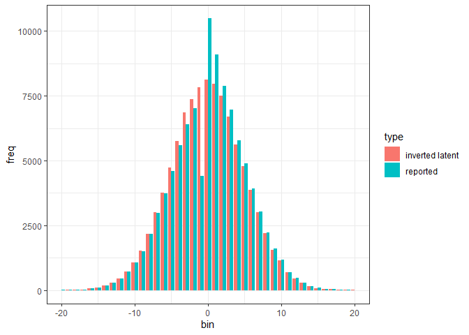

```r
df_pi_x <- full_join(df_pi, df_x, by = 'bin') %>%
  pivot_longer(-bin, names_to = 'type', values_to = 'freq')

g <- ggplot(df_pi_x, aes(x = bin, y = freq, fill = type)) +
  geom_bar(aes(fill = type), stat = 'identity', position = 'dodge', alpha =1 )+
  xlim(-20,20) +
  scale_fill_hue(name = "type", labels = c(count_e = "inverted latent", count_R ='reported')) +
  theme_bw()

plot(g)
```

## Step 4 Optimizetion

- Lastly, using SMM, I estimate the parameter.
  - This estimation method might be problematic since the “moment condition” is not grounded on theory.
- The objective function is
  $$L(\theta) = \left[\left(\begin{array}{l}
  \pi\\
  \boldsymbol{x}_{S}(\theta)_{(2,\ldots T)}
  \end{array}\right)-\left(\begin{array}{l}
  \boldsymbol{x}_{S}(\theta)\\
  \boldsymbol{x}_{S}(\theta)_{(1,\ldots T-1)}
  \end{array}\right)\right]^{\prime}\Omega\left[\left(\begin{array}{l}
  \pi\\
  \boldsymbol{x}_{S}(\theta)_{(2,\ldots T)}
  \end{array}\right)-\left(\begin{array}{l}
  \boldsymbol{x}_{S}(\theta)\\
  \boldsymbol{x}_{S}(\theta)_{(1,\ldots T-1)}
  \end{array}\right)\right]$$
- `GMM_objective.R` computes the value of objective function for a candidate set of parameters.
  - This function proceeds as follows:
  - Compute $P$ by `compute_P.R`.
  - Compute $\pi$ and $x$ by `compute_x.R` and `compute_pi.R`
  - Compute the objective funciton.

```r
GMM_objective
```

```
function(theta, df_observed, S = 1000){
  # This function returns the GMM objective function ('criterion function') to optimize theta.

  # recover P
  P <- compute_P(theta, S)

  # observed distribution
  df_pi <- compute_pi(df_observed)

  pi <- df_pi %>% pull(count_R)

  # latent distribution and adjacent bins
  df_x <- compute_x(P, df_pi)

  x <- df_x %>% pull(count_e)

  smoothness <- df_x %>%
    mutate(lag_e = lag(count_e)) %>%
    mutate(smoothness = count_e - lag_e) %>%
    drop_na() %>%      # for the first row the lagged variable (left bin) does not exist
    pull(smoothness)

  # vector
  obj <- c(pi - x, smoothness)

  # GMM objective

  # TODO: what weighting matrix?


  return(sum(obj^2))
}
<bytecode: 0x000000002e0f2370>
<environment: namespace:NumbersGame>
```

- Finally, I optimize the GMM objective function.
  - In optimization, the number of simulation, $S$, should be at least $100,000$ to get a reasonable result.
  - However, since this optimization takes a lot of time, I set $S = 10,000$.
  - Delete the commentout to execute the optimization.

```r
# # Nelder-Mead
# optim_result <- optim(par = c(0.5, 2, 1, 4),
#                       fn = GMM_objective,
#                       df_observed = df_observed,
#                       S = 10000,
#                       method = 'Nelder-Mead')
#
# # optim_result <- optim(par = c(0.5, 2, 1, 4),
# #                       fn = GMM_objective,
# #                       df_observed = df_observed,
# #                       method = 'L-BFGS-B',
# #                       lower = c(0.001, 1, 0, 0),
# #                       upper = c(2, 4, 2, 5),
# #                       control = list(maxit = 50))
# optim_result
```

- Let’s see the shape of objective function w.r.t. each parameter.

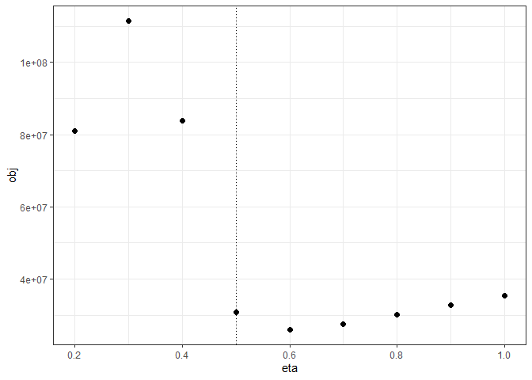

```r
S <- 50000

eta <- seq(0.2, 1, .1)
plot_objFunc(theta, 1, eta, df_observed, S = S)
```

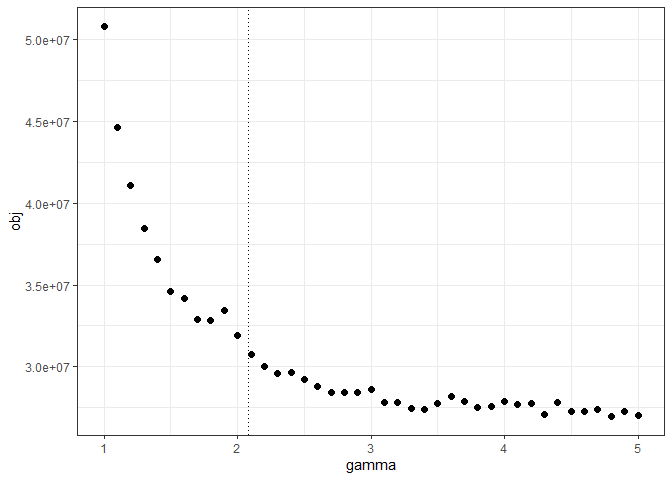

```r
gamma <- seq(1, 5, .1)
plot_objFunc(theta, 2, gamma, df_observed, S = S)
```

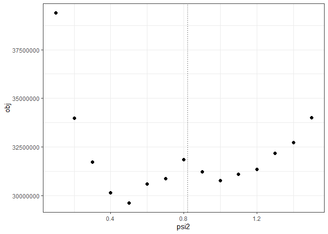

```r
psi2 <- seq(0.1, 1.5, .1)
plot_objFunc(theta, 3, psi2, df_observed, S = S)
```

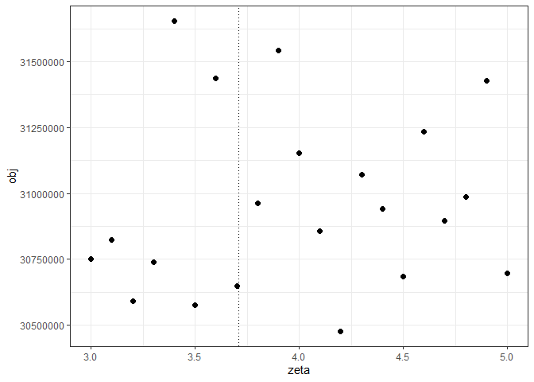

```r
zeta <- seq(3, 5, .1)
plot_objFunc(theta, 4, zeta, df_observed, S = S)
```

##### Computational burdern of BKR method

- Let’s see the time it take for each iteration given the number of simulations.
  - Notice that these times are obtained with parallelized computation (`compute_P` is parallelized.)

```r
S <- 1000
system.time(GMM_objective(theta_init, df_observed, S))
```

```
   user  system elapsed
   0.16    0.11   12.41
```

```r
S <- 10000
system.time(GMM_objective(theta_init, df_observed, S))
```

```
   user  system elapsed
   0.15    0.14   98.26
```

```r
S <- 100000
system.time(GMM_objective(theta_init, df_observed, S))
```

```
   user  system elapsed
   1.59    0.26  940.98
```

### Original simulated obj

```r
CMD_obj
```

```
function(theta, df_observed, df_simulated, S){

  ###### observed MLE ######
  df_reported <- count_all_bins(df_observed) %>%
    mutate(p_obs_MLE = count / sum(count))
  p_obs_MLE <- df_reported %>% pull(p_obs_MLE)


  ###### simulated MLE ######
  # optimal behavior
  df_simulated_manipulation <- compute_optimal_manipulation_simulated(df_simulated, theta, S) %>%
    select(firm, R) %>%
    count_all_bins() %>%
    mutate(p_simulated_MLE = count / sum(count))
  p_simulated_MLE <- df_simulated_manipulation %>% pull(p_simulated_MLE)

  ##### objective function #####
  obj <- sum( (100*p_obs_MLE - 100*p_simulated_MLE)^2 )

  return(obj)
}
<bytecode: 0x000000002ac062b0>
<environment: namespace:NumbersGame>
```

```r
# simulate data
S <- 100000
df_simulated <- simulate_firm(sigma = 5, S)

# optimization
optim_result <- optimx::optimx(par = 0.3,
                               theta = c(gamma, psi2, zeta),
                               fn = CMD_obj_eta,
                               df_observed = df_observed,
                               df_simulated = df_simulated,
                               S = S,
                               method = 'BFGS')
optim_result
```

```
           p1    value fevals gevals niter convcode  kkt1 kkt2   xtime
BFGS 151.0802 18.41377     68      6    NA        0 FALSE TRUE 5178.64
```

- Let’s see the shape of objective function around each true parameter.

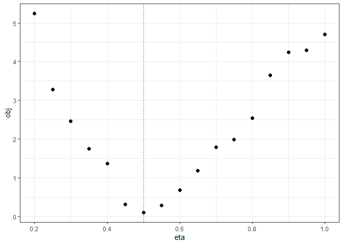

```r
graphs_CMD <- list()

eta <- seq(0.2, 1, .05)
graphs_CMD[[1]] <- plot_objFunc_CMD(theta, 1, eta,  df_observed = df_observed, df_simulated = df_simulated, S = S, parallel = TRUE)
```

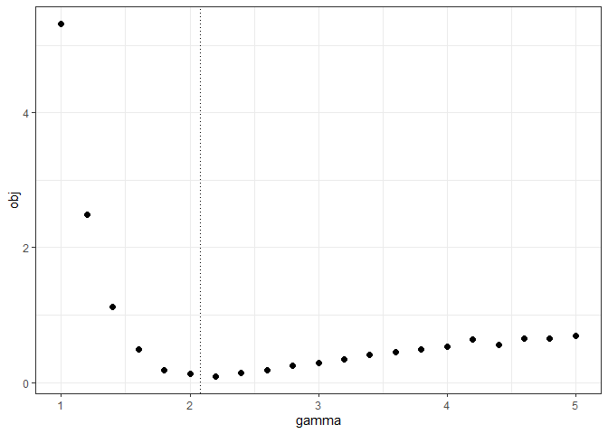

```r
gamma <- seq(1, 5, .2)
graphs_CMD[[2]] <- plot_objFunc_CMD(theta, 2, gamma, df_simulated, df_observed,  S = S, parallel = TRUE)
```

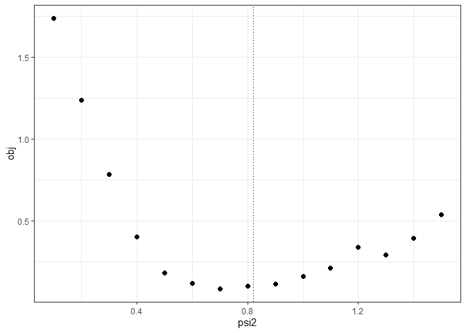

```r
psi2 <- seq(0.1, 1.5, .1)
graphs_CMD[[3]] <- plot_objFunc_CMD(theta, 3, psi2, df_simulated, df_observed,  S = S, parallel = TRUE)
```

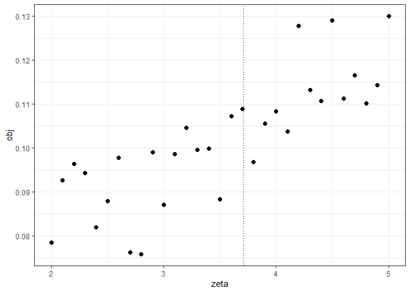

```r
zeta <- seq(2, 5, .1)
graphs_CMD[[4]] <- plot_objFunc_CMD(theta, 4, zeta, df_simulated, df_observed,  S = S, parallel = TRUE)
```

```r
for(i in 1:4){
  ggsave(plot = graphs_CMD[[i]], file = paste0( '../output/plots/CMD_objectives_', i, '.png'))
}
```

##### Computational burdern of the alternative method

- Let’s see the time it take for each iteration given the number of simulations.
  - Notice that these computations are NOT paralleled unlike BKR method.

```r
S <- 1000
df_simulated <- simulate_firm(sigma, S)
system.time(CMD_obj(theta, df_observed, df_simulated, S))
```

```
   user  system elapsed
   1.44    0.00    1.56
```

```r
S <- 10000
df_simulated <- simulate_firm(sigma, S)
system.time(CMD_obj(theta, df_observed, df_simulated, S))
```

```
   user  system elapsed
  12.74    0.03   13.51
```

```r
S <- 100000
df_simulated <- simulate_firm(sigma, S)
system.time(CMD_obj(theta, df_observed, df_simulated, S))
```

```
   user  system elapsed
 114.27    1.28  126.65
```

## Counterfacturals

- See what happens if we increase the marginal cost parameter, $\eta$.
  - Since manipulation becomes more costly, firms that find manipulation beneficial are limited to just below the zero threshold.

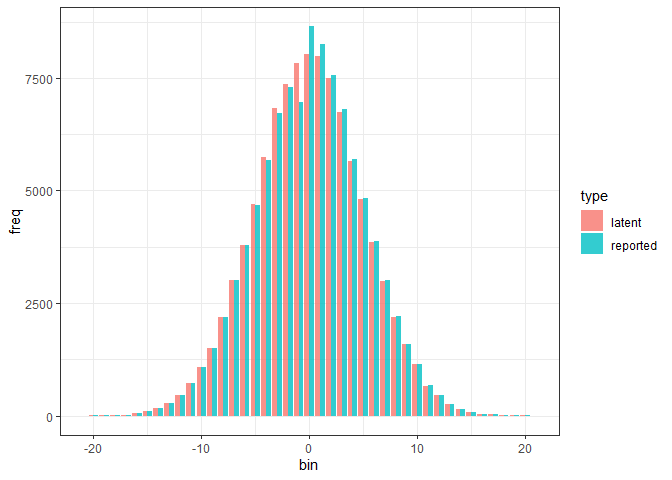

```r
theta_new <- theta
theta_new[1] <- 2     # increase the marginal cost to one

df_firm_utility_new <- compute_optimal_manipulation_simulated(df_firm, theta = theta_new, S = N)
plot_latent_reported(df_firm_utility_new)
```

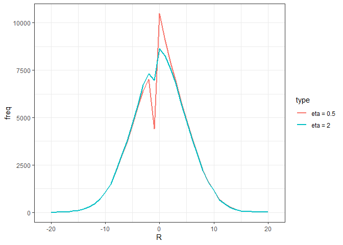

```r
df_firm_utility_aggregated <- df_firm_utility %>%
  group_by(R) %>%
  summarise('eta = 0.5' = n())

df_firm_utility_new_aggregated <- df_firm_utility_new %>%
  group_by(R) %>%
  summarise('eta = 2' = n())

df_compare = left_join(df_firm_utility_aggregated, df_firm_utility_new_aggregated) %>% pivot_longer(-R, names_to = 'type', values_to = 'freq')

ggplot(df_compare, aes(x = R, y = freq, fill = type)) +
    geom_line(aes(color = type), size = 1)+
    xlim(-21,21) +
    theme_bw()
```